# Functions in SamplingStrata package - II

Marco Ballin, Giulio Barcaroli

20 May 2019

# Implementation with only continuous stratification variables

Function *optimizeStrata2* performs the same task than *optimizeStrata*, but with a different Genetic Algorithm, operating on a genome represented by vector containing real values, instead of integers. This permits to operate directly on the boundaries of the strata, instead of aggregating the initial atomic strata. In some situations (not exceedingly too big size of the sampling frame) this new function is much more efficient. Furthermore, resulting strata are guaranteed to not overlap with respect to the different stratification variables. A major limitation is in the nature of the stratification variables, that are required to be all continuous (though categorical ordinal can be handled). Another one is in the fact that it is necessary to choose the number of strata (it is not optimally determined during the evolution process as in the case of *optimizeStrata*).

# Necessary steps with only continuous stratification variables

To operate with *optimizeStrata2* it is no more necessary to produce the *strata* dataframe.

We just need to perform the following steps:

- construction of the **sampling frame**
- choice of **precision constraints**
- **optimization**
- **analysis** of results
- **selection of the sample**

# Construction of the sampling frame

Let us consider the following example:

```r
data("swissmunicipalities")
swissmunicipalities$id <- c(1:nrow(swissmunicipalities))
swissmunicipalities$dom <- 1
frame <- buildFrameDF(swissmunicipalities,
                      id = "id",
                      domainvalue = "REG",
                      X = c("Surfacesbois","Surfacescult"),
                      Y = c("Pop020", "Pop2040")
)
# choice of units to be selected in any case (census units)
framecens <- frame[frame$X1 > 2500
                   | frame$X2 > 1200,]
# remaining units
framesamp <- frame[!(frame$id %in% framecens$id),]
```

# Choice of precision constraints

```r
cv <- NULL
cv$DOM <- "DOM1"
cv$CV1 <- 0.1
cv$CV2 <- 0.1
cv <- as.data.frame(cv)
cv <- cv[rep(row.names(cv),7),]
cv$domainvalue <- c(1:7)
cv
```

```
##      DOM CV1 CV2 domainvalue
## 1   DOM1 0.1 0.1           1
## 1.1 DOM1 0.1 0.1           2
## 1.2 DOM1 0.1 0.1           3
## 1.3 DOM1 0.1 0.1           4
## 1.4 DOM1 0.1 0.1           5
## 1.5 DOM1 0.1 0.1           6
## 1.6 DOM1 0.1 0.1           7
```

By so doing, we have chosen two stratification variables (*Surfacesbois* and *Surfacescult*) and two target variables (*Pop020* and *Pop2040*), on both of which we have set the same precision constraint (a maximum CV equal to 10%).

# Optimization

Now the execution of the optimization step (for the domain 4) using *optimizeStrata2* is straightforward, as we do not need to categorize stratification variables and to generate the atomic strata:

```
##
##  *** Sample cost:  34.31101
##  *** Number of strata:  5
```

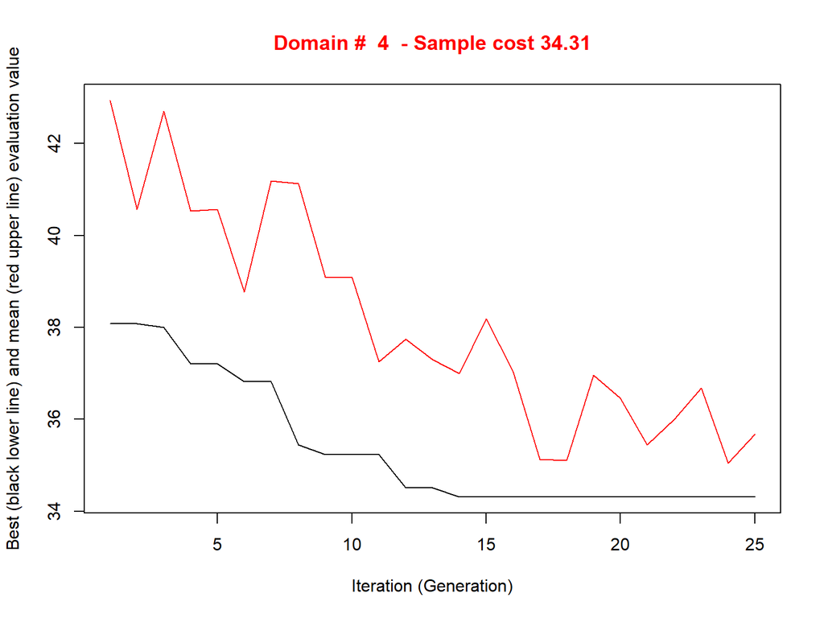

```
##
##  *** Sample size :  29
##  *** Number of strata :  5
## ---------------------------
```

```r
solution <- optimizeStrata2 (
  errors = cv,
  framesamp = framesamp,
  framecens = framecens,
  strcens = TRUE,
  alldomains = FALSE,
  dom = 4,
  iter = 25,
  pops = 20,
  nStrata = 5,
  writeFiles = FALSE,
  showPlot = FALSE,
  parallel = FALSE
)
```

# Optimization

```r
sum(round(solution$aggr_strata$SOLUZ))
```

```
## [1] 35
```

```r
expected_CV(solution$aggr_strata)
```

```
##      cv(Y1) cv(Y2)
## DOM1    0.1    0.1
```

This function also outputs the new version of the overall frame (sampling plus census), already provided with the labels indicating to which stratum each unit belongs:

```r
framenew <- solution$framenew
table(framenew$LABEL)
```

```
##
##  1  2  3  4  5  6
## 81 14 38 27  5  6
```

The first 5 strata are the ones pertaining to sampling units, the 6th is the one with censused units.

# Analysis of the results

To inspect the structure of the strata, the function *summaryStrata* is available:

```r
strataStructure <- summaryStrata(solution$framenew,solution$aggr_strata,progress=FALSE)
strataStructure
```

```
##   Domain Stratum Population Allocation SamplingRate Lower_X1 Upper_X1
## 1      4       1         81          9     0.110121        5      231
## 2      4       2         14          4     0.266773      167      270
## 3      4       3         38          6     0.152084      172      509
## 4      4       4         27          5     0.180635      125     1126
## 5      4       5          5          5     1.000000      168     2326
## 6      4       6          6          6     1.000000      261     2807
##   Lower_X2 Upper_X2
## 1       40      547
## 2      160      553
## 3      165      641
## 4      440      890
## 5      853     1142
## 6     1204     1827
```

# Analysis of the results

It is also possible to visually investigate the distribution of population units in the strata by using the function *plotStrata2d*:

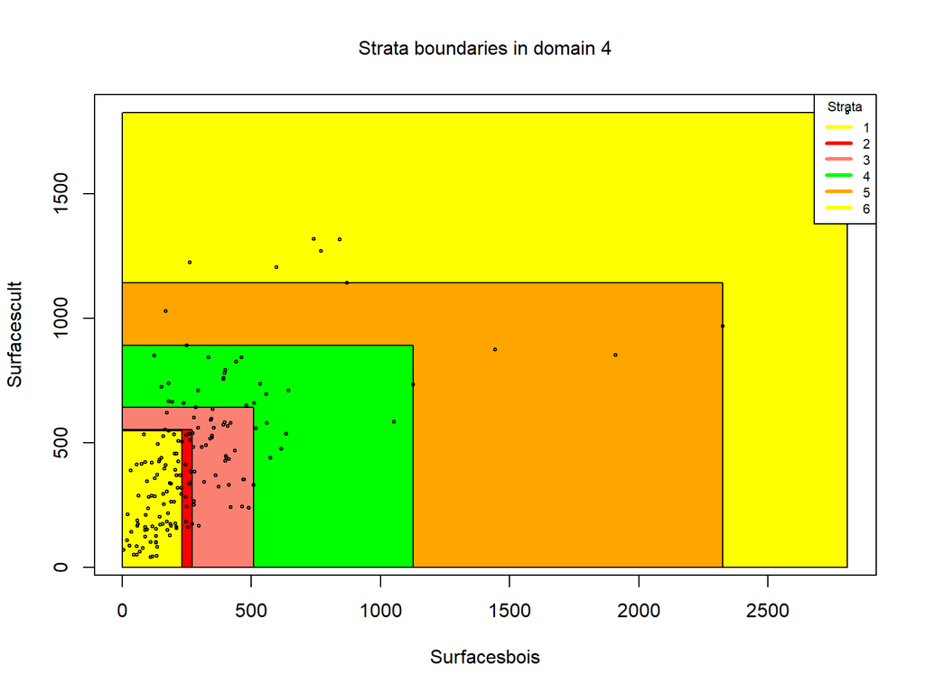

```r
outstrata <- plotStrata2d(
                  solution$framenew,
                  solution$aggr_strata,
                  domain = 4,
                  vars = c("X1","X2"),
                  labels =     c("Surfacesbois","Surfacescult")
                  )
```

# Analysis of the results

Together with the plot, also a tabular format of the optimized strata is produced by *plotStrata2d*:

```r
outstrata
```

| Stratum | Population | Allocation | SamplingRate | Bounds Surfacesbois | Bounds Surfacescult |
| --- | --- | --- | --- | --- | --- |
| 1 | 81 | 9 | 0.1101214 | 5-231 | 40-547 |
| 2 | 14 | 4 | 0.2667731 | 167-270 | 160-553 |
| 3 | 38 | 6 | 0.1520844 | 172-509 | 165-641 |
| 4 | 27 | 5 | 0.1806351 | 125-1126 | 440-890 |
| 5 | 5 | 5 | 1.0000000 | 168-2326 | 853-1142 |
| 6 | 6 | 6 | 1.0000000 | 261-2807 | 1204-1827 |

# Selection of the sample

Finally, the selection of the sample is performed by using the same function selectSample, but this time is no more necessary to handle separately units to be sampled and units to be censused:

```r
samp <- selectSample(solution$framenew,solution$aggr_strata)
```

```
##
## *** Sample has been drawn successfully ***
##  35  units have been selected from  6  strata
##
## ==> There have been  2  take-all strata
## from which have been selected  11 units
```